# online_retail_eda

## 📊 Exploratory Data Analysis (EDA) — Online Retail

### 1. Tổng quan dữ liệu

Tập dữ liệu bao gồm các giao dịch mua hàng tại siêu thị trực tuyến trong một giai đoạn nhất định.  
Mỗi dòng biểu diễn một **mặt hàng trong một đơn hàng** với các thông tin: mã đơn, mã sản phẩm, số lượng, đơn giá, ngày mua, mã khách hàng và quốc gia.

Sau khi làm sạch dữ liệu:

```python
import warnings
warnings.filterwarnings("ignore")

import pandas as pd
import numpy as np
import matplotlib.pyplot as plt
import seaborn as sns

# display helper (in notebook)
from IPython.display import display
plt.rcParams["figure.figsize"] = (10,5)
```

```python
# Try reading only needed columns to avoid long parse times:
usecols = ["InvoiceNo","StockCode","Description","Quantity","InvoiceDate","UnitPrice","CustomerID","Country"]
df = pd.read_excel("online_retail.xlsx", usecols=usecols, engine="openpyxl")

# Quick confirm
print("Shape:", df.shape)
display(df.head())
```

```
Shape: (541909, 8)
```

|  | InvoiceNo | StockCode | Description | Quantity | InvoiceDate | UnitPrice | CustomerID | Country |
| --- | --- | --- | --- | --- | --- | --- | --- | --- |
| 0 | 536365 | 85123A | WHITE HANGING HEART T-LIGHT HOLDER | 6 | 2010-12-01 08:26:00 | 2.55 | 17850.0 | United Kingdom |
| 1 | 536365 | 71053 | WHITE METAL LANTERN | 6 | 2010-12-01 08:26:00 | 3.39 | 17850.0 | United Kingdom |
| 2 | 536365 | 84406B | CREAM CUPID HEARTS COAT HANGER | 8 | 2010-12-01 08:26:00 | 2.75 | 17850.0 | United Kingdom |
| 3 | 536365 | 84029G | KNITTED UNION FLAG HOT WATER BOTTLE | 6 | 2010-12-01 08:26:00 | 3.39 | 17850.0 | United Kingdom |
| 4 | 536365 | 84029E | RED WOOLLY HOTTIE WHITE HEART. | 6 | 2010-12-01 08:26:00 | 3.39 | 17850.0 | United Kingdom |

```python
# Thông tin cơ bản
display(df.info())
display(df.describe(include="all").T)

# Missing values
missing = df.isna().sum().to_frame("missing_count")
missing["missing_pct"] = (missing["missing_count"] / len(df) * 100).round(2)
display(missing.sort_values("missing_pct", ascending=False))
```

```
<class 'pandas.core.frame.DataFrame'>
RangeIndex: 541909 entries, 0 to 541908
Data columns (total 8 columns):
 #   Column       Non-Null Count   Dtype
---  ------       --------------   -----
 0   InvoiceNo    541909 non-null  object
 1   StockCode    541909 non-null  object
 2   Description  540455 non-null  object
 3   Quantity     541909 non-null  int64
 4   InvoiceDate  541909 non-null  datetime64[ns]
 5   UnitPrice    541909 non-null  float64
 6   CustomerID   406829 non-null  float64
 7   Country      541909 non-null  object
dtypes: datetime64[ns](1), float64(2), int64(1), object(4)
memory usage: 33.1+ MB
```

```
None
```

|  | count | unique | top | freq | mean | min | 25% | 50% | 75% | max | std |
| --- | --- | --- | --- | --- | --- | --- | --- | --- | --- | --- | --- |
| InvoiceNo | 541909.0 | 25900.0 | 573585.0 | 1114.0 | NaN | NaN | NaN | NaN | NaN | NaN | NaN |
| StockCode | 541909 | 4070 | 85123A | 2313 | NaN | NaN | NaN | NaN | NaN | NaN | NaN |
| Description | 540455 | 4223 | WHITE HANGING HEART T-LIGHT HOLDER | 2369 | NaN | NaN | NaN | NaN | NaN | NaN | NaN |
| Quantity | 541909.0 | NaN | NaN | NaN | 9.55225 | -80995.0 | 1.0 | 3.0 | 10.0 | 80995.0 | 218.081158 |
| InvoiceDate | 541909 | NaN | NaN | NaN | 2011-07-04 13:34:57.156386048 | 2010-12-01 08:26:00 | 2011-03-28 11:34:00 | 2011-07-19 17:17:00 | 2011-10-19 11:27:00 | 2011-12-09 12:50:00 | NaN |
| UnitPrice | 541909.0 | NaN | NaN | NaN | 4.611114 | -11062.06 | 1.25 | 2.08 | 4.13 | 38970.0 | 96.759853 |
| CustomerID | 406829.0 | NaN | NaN | NaN | 15287.69057 | 12346.0 | 13953.0 | 15152.0 | 16791.0 | 18287.0 | 1713.600303 |
| Country | 541909 | 38 | United Kingdom | 495478 | NaN | NaN | NaN | NaN | NaN | NaN | NaN |

|  | missing_count | missing_pct |
| --- | --- | --- |
| CustomerID | 135080 | 24.93 |
| Description | 1454 | 0.27 |
| StockCode | 0 | 0.00 |
| InvoiceNo | 0 | 0.00 |
| Quantity | 0 | 0.00 |
| InvoiceDate | 0 | 0.00 |
| UnitPrice | 0 | 0.00 |
| Country | 0 | 0.00 |

```python
# 1. convert InvoiceDate
df["InvoiceDate"] = pd.to_datetime(df["InvoiceDate"], errors="coerce")

# 2. drop exact duplicates (không khuyến khích xóa)
dup_count = df.duplicated().sum()
print("Duplicate rows:", dup_count)
# df = df.drop_duplicates()

# 3. create TotalPrice
df["TotalPrice"] = df["Quantity"] * df["UnitPrice"]

# 4. flag returns (InvoiceNo starts with 'C' or negative qty)
df["IsReturn"] = df["InvoiceNo"].astype(str).str.startswith("C") | (df["Quantity"] < 0)

# 5. InvoiceMonth for time series
df["InvoiceMonth"] = df["InvoiceDate"].dt.to_period("M")

display(df.head())
```

```
Duplicate rows: 5268
```

|  | InvoiceNo | StockCode | Description | Quantity | InvoiceDate | UnitPrice | CustomerID | Country | TotalPrice | IsReturn | InvoiceMonth |
| --- | --- | --- | --- | --- | --- | --- | --- | --- | --- | --- | --- |
| 0 | 536365 | 85123A | WHITE HANGING HEART T-LIGHT HOLDER | 6 | 2010-12-01 08:26:00 | 2.55 | 17850.0 | United Kingdom | 15.30 | False | 2010-12 |
| 1 | 536365 | 71053 | WHITE METAL LANTERN | 6 | 2010-12-01 08:26:00 | 3.39 | 17850.0 | United Kingdom | 20.34 | False | 2010-12 |
| 2 | 536365 | 84406B | CREAM CUPID HEARTS COAT HANGER | 8 | 2010-12-01 08:26:00 | 2.75 | 17850.0 | United Kingdom | 22.00 | False | 2010-12 |
| 3 | 536365 | 84029G | KNITTED UNION FLAG HOT WATER BOTTLE | 6 | 2010-12-01 08:26:00 | 3.39 | 17850.0 | United Kingdom | 20.34 | False | 2010-12 |
| 4 | 536365 | 84029E | RED WOOLLY HOTTIE WHITE HEART. | 6 | 2010-12-01 08:26:00 | 3.39 | 17850.0 | United Kingdom | 20.34 | False | 2010-12 |

### 2. Thống kê mô tả

Phân tích các chỉ số trung tâm và độ phân tán cho các biến số cho thấy:

[output not shown]

Nhìn chung, dữ liệu có **phân phối lệch phải mạnh (right-skewed)**, nghĩa là phần lớn giao dịch có giá trị thấp, chỉ vài giao dịch tạo doanh thu cực lớn.

```python
# Thống kê mô tả
num_cols = df.select_dtypes(include=[np.number]).columns.tolist()
desc = df[num_cols].describe().T

# Add median, IQR
desc["median"] = df[num_cols].median()
desc["IQR"] = df[num_cols].quantile(0.75) - df[num_cols].quantile(0.25)
display(desc.round(3))
```

|  | count | mean | std | min | 25% | 50% | 75% | max | median | IQR |
| --- | --- | --- | --- | --- | --- | --- | --- | --- | --- | --- |
| Quantity | 541909.0 | 9.552 | 218.081 | -80995.00 | 1.00 | 3.00 | 10.00 | 80995.0 | 3.00 | 9.00 |
| UnitPrice | 541909.0 | 4.611 | 96.760 | -11062.06 | 1.25 | 2.08 | 4.13 | 38970.0 | 2.08 | 2.88 |
| CustomerID | 406829.0 | 15287.691 | 1713.600 | 12346.00 | 13953.00 | 15152.00 | 16791.00 | 18287.0 | 15152.00 | 2838.00 |
| TotalPrice | 541909.0 | 17.988 | 378.811 | -168469.60 | 3.40 | 9.75 | 17.40 | 168469.6 | 9.75 | 14.00 |

```python
# e.g., zero or negative unit price, zero quantity, zero or unrealistic values:
print("Quantity <=0:", (df["Quantity"] <= 0).sum())
print("UnitPrice <=0:", (df["UnitPrice"] <= 0).sum())
print("TotalPrice <=0:", (df["TotalPrice"] <= 0).sum())

# Show some rows that look suspicious
display(df[(df["Quantity"]<=0) | (df["UnitPrice"]<=0)].head(10))
```

```
Quantity <=0: 10624
UnitPrice <=0: 2517
TotalPrice <=0: 11805
```

|  | InvoiceNo | StockCode | Description | Quantity | InvoiceDate | UnitPrice | CustomerID | Country | TotalPrice | IsReturn | InvoiceMonth |
| --- | --- | --- | --- | --- | --- | --- | --- | --- | --- | --- | --- |
| 141 | C536379 | D | Discount | -1 | 2010-12-01 09:41:00 | 27.50 | 14527.0 | United Kingdom | -27.50 | True | 2010-12 |
| 154 | C536383 | 35004C | SET OF 3 COLOURED FLYING DUCKS | -1 | 2010-12-01 09:49:00 | 4.65 | 15311.0 | United Kingdom | -4.65 | True | 2010-12 |
| 235 | C536391 | 22556 | PLASTERS IN TIN CIRCUS PARADE | -12 | 2010-12-01 10:24:00 | 1.65 | 17548.0 | United Kingdom | -19.80 | True | 2010-12 |
| 236 | C536391 | 21984 | PACK OF 12 PINK PAISLEY TISSUES | -24 | 2010-12-01 10:24:00 | 0.29 | 17548.0 | United Kingdom | -6.96 | True | 2010-12 |
| 237 | C536391 | 21983 | PACK OF 12 BLUE PAISLEY TISSUES | -24 | 2010-12-01 10:24:00 | 0.29 | 17548.0 | United Kingdom | -6.96 | True | 2010-12 |
| 238 | C536391 | 21980 | PACK OF 12 RED RETROSPOT TISSUES | -24 | 2010-12-01 10:24:00 | 0.29 | 17548.0 | United Kingdom | -6.96 | True | 2010-12 |
| 239 | C536391 | 21484 | CHICK GREY HOT WATER BOTTLE | -12 | 2010-12-01 10:24:00 | 3.45 | 17548.0 | United Kingdom | -41.40 | True | 2010-12 |
| 240 | C536391 | 22557 | PLASTERS IN TIN VINTAGE PAISLEY | -12 | 2010-12-01 10:24:00 | 1.65 | 17548.0 | United Kingdom | -19.80 | True | 2010-12 |
| 241 | C536391 | 22553 | PLASTERS IN TIN SKULLS | -24 | 2010-12-01 10:24:00 | 1.65 | 17548.0 | United Kingdom | -39.60 | True | 2010-12 |
| 622 | 536414 | 22139 | NaN | 56 | 2010-12-01 11:52:00 | 0.00 | NaN | United Kingdom | 0.00 | False | 2010-12 |

```python
top_products_qty = df.groupby("Description")["Quantity"].sum().sort_values(ascending=False).head(10).reset_index()
top_products_rev = df.groupby("Description")["TotalPrice"].sum().sort_values(ascending=False).head(10).reset_index()
top_customers = df.groupby("CustomerID")["TotalPrice"].sum().sort_values(ascending=False).head(10).reset_index()
top_countries = df.groupby("Country")["TotalPrice"].sum().sort_values(ascending=False).head(10).reset_index()

display(top_products_qty)
display(top_products_rev)
display(top_customers)
display(top_countries)
```

|  | Description | Quantity |
| --- | --- | --- |
| 0 | WORLD WAR 2 GLIDERS ASSTD DESIGNS | 53847 |
| 1 | JUMBO BAG RED RETROSPOT | 47363 |
| 2 | ASSORTED COLOUR BIRD ORNAMENT | 36381 |
| 3 | POPCORN HOLDER | 36334 |
| 4 | PACK OF 72 RETROSPOT CAKE CASES | 36039 |
| 5 | WHITE HANGING HEART T-LIGHT HOLDER | 35317 |
| 6 | RABBIT NIGHT LIGHT | 30680 |
| 7 | MINI PAINT SET VINTAGE | 26437 |
| 8 | PACK OF 12 LONDON TISSUES | 26315 |
| 9 | PACK OF 60 PINK PAISLEY CAKE CASES | 24753 |

|  | Description | TotalPrice |
| --- | --- | --- |
| 0 | DOTCOM POSTAGE | 206245.48 |
| 1 | REGENCY CAKESTAND 3 TIER | 164762.19 |
| 2 | WHITE HANGING HEART T-LIGHT HOLDER | 99668.47 |
| 3 | PARTY BUNTING | 98302.98 |
| 4 | JUMBO BAG RED RETROSPOT | 92356.03 |
| 5 | RABBIT NIGHT LIGHT | 66756.59 |
| 6 | POSTAGE | 66230.64 |
| 7 | PAPER CHAIN KIT 50'S CHRISTMAS | 63791.94 |
| 8 | ASSORTED COLOUR BIRD ORNAMENT | 58959.73 |
| 9 | CHILLI LIGHTS | 53768.06 |

|  | CustomerID | TotalPrice |
| --- | --- | --- |
| 0 | 14646.0 | 279489.02 |
| 1 | 18102.0 | 256438.49 |
| 2 | 17450.0 | 187482.17 |
| 3 | 14911.0 | 132572.62 |
| 4 | 12415.0 | 123725.45 |
| 5 | 14156.0 | 113384.14 |
| 6 | 17511.0 | 88125.38 |
| 7 | 16684.0 | 65892.08 |
| 8 | 13694.0 | 62653.10 |
| 9 | 15311.0 | 59419.34 |

|  | Country | TotalPrice |
| --- | --- | --- |
| 0 | United Kingdom | 8187806.364 |
| 1 | Netherlands | 284661.540 |
| 2 | EIRE | 263276.820 |
| 3 | Germany | 221698.210 |
| 4 | France | 197403.900 |
| 5 | Australia | 137077.270 |
| 6 | Switzerland | 56385.350 |
| 7 | Spain | 54774.580 |
| 8 | Belgium | 40910.960 |
| 9 | Sweden | 36595.910 |

### 3. Doanh thu và sản phẩm

Phân tích tổng doanh thu (`TotalPrice`) cho thấy:

```python
# Doanh thu hàng tháng
sales = df[~df["IsReturn"]].copy()
monthly = sales.groupby("InvoiceMonth")["TotalPrice"].sum().reset_index()
monthly["InvoiceMonth"] = monthly["InvoiceMonth"].astype(str)
display(monthly.head(12))
```

|  | InvoiceMonth | TotalPrice |
| --- | --- | --- |
| 0 | 2010-12 | 823746.140 |
| 1 | 2011-01 | 691364.560 |
| 2 | 2011-02 | 523631.890 |
| 3 | 2011-03 | 717639.360 |
| 4 | 2011-04 | 537808.621 |
| 5 | 2011-05 | 770536.020 |
| 6 | 2011-06 | 761739.900 |
| 7 | 2011-07 | 719221.191 |
| 8 | 2011-08 | 737014.260 |
| 9 | 2011-09 | 1058590.172 |
| 10 | 2011-10 | 1154979.300 |
| 11 | 2011-11 | 1509496.330 |

### 4. Phân tích thời gian (Time Series)

- Khi nhóm theo tháng (`InvoiceMonth`), đường biểu đồ doanh thu cho thấy **xu hướng tăng dần** theo thời gian, xen kẽ với **các tháng doanh thu đột biến** (thường trùng thời điểm lễ tết).
- Sự dao động doanh thu hàng tháng phản ánh **tính thời vụ và hành vi mua sắm** (người tiêu dùng tăng mua vào dịp đặc biệt).

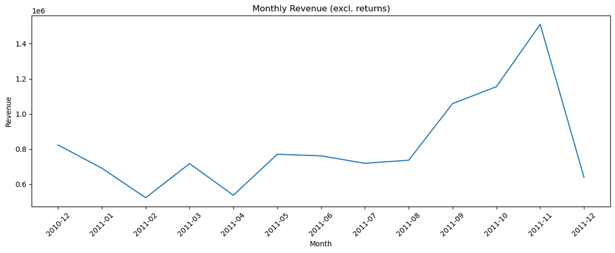

```python
# Doanh thu hàng tháng
plt.figure(figsize=(12,5))
plt.plot(monthly["InvoiceMonth"], monthly["TotalPrice"])
plt.xticks(rotation=45)
plt.xlabel("Month")
plt.ylabel("Revenue")
plt.title("Monthly Revenue (excl. returns)")
plt.tight_layout()
plt.show()
```

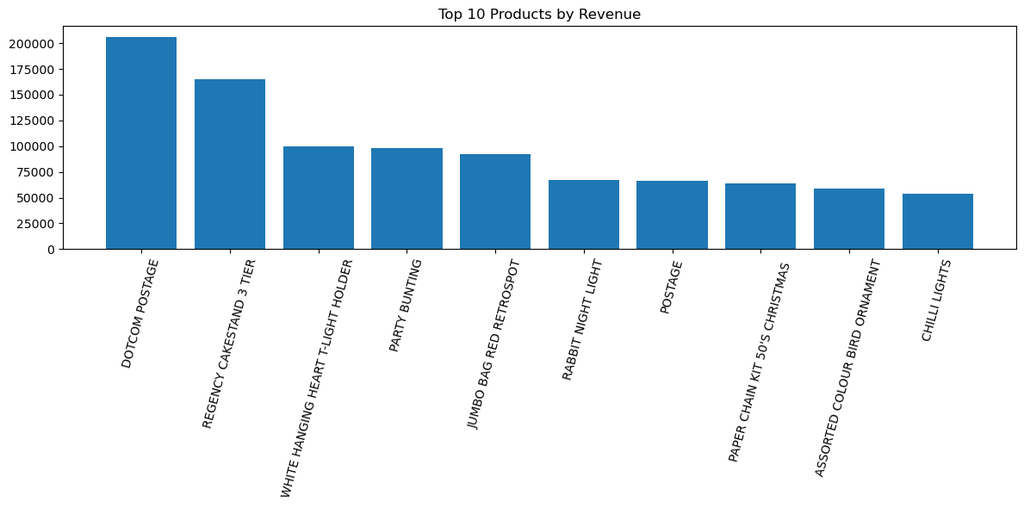

```python
# Top 10 sản phẩm sắp xếp bởi doanh thu
plt.figure(figsize=(12,6))
plt.bar(top_products_rev["Description"], top_products_rev["TotalPrice"])
plt.xticks(rotation=75)
plt.title("Top 10 Products by Revenue")
plt.tight_layout()
plt.show()
```

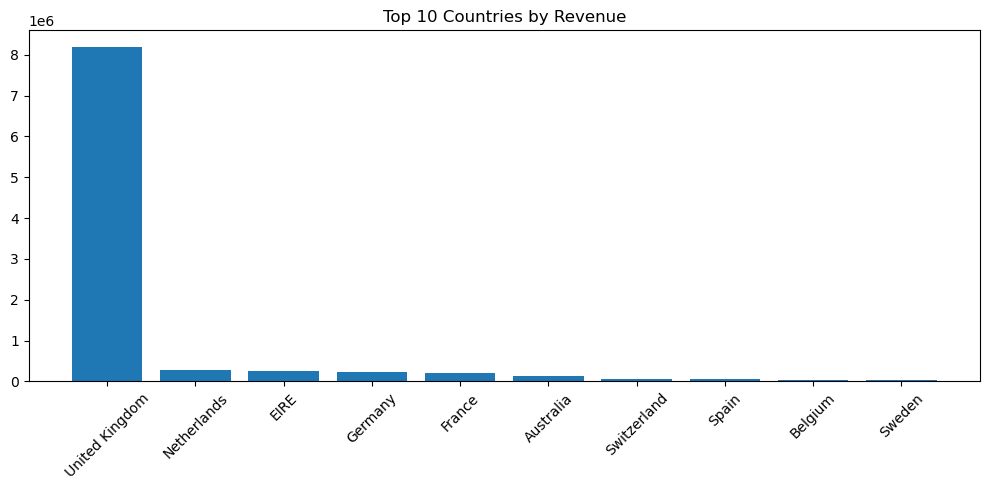

```python
# Top 10 quốc gia sắp xếp bởi doanh thu
plt.figure(figsize=(10,5))
plt.bar(top_countries["Country"], top_countries["TotalPrice"])
plt.xticks(rotation=45)
plt.title("Top 10 Countries by Revenue")
plt.tight_layout()
plt.show()
```

### 5. Phân tích tương quan (Correlation Analysis)

Biểu đồ heatmap giữa `Quantity`, `UnitPrice`, `TotalPrice` cho thấy:

```
            Quantity  UnitPrice  TotalPrice
Quantity    1.000000  -0.001235    0.886681
UnitPrice  -0.001235   1.000000   -0.162029
TotalPrice  0.886681  -0.162029    1.000000
```

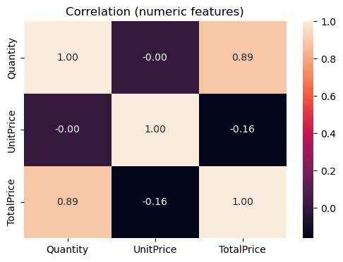

```python
# Biểu đồ heatmap
num = ["Quantity","UnitPrice","TotalPrice"]
corr = df[num].corr()
print(corr)

# heatmap with seaborn (optional)
plt.figure(figsize=(6,4))
sns.heatmap(corr, annot=True, fmt=".2f")
plt.title("Correlation (numeric features)")
plt.show()
```

### 6. Phát hiện ngoại lai (Outliers)

Qua boxplot, cả ba biến `Quantity`, `UnitPrice` và `TotalPrice` đều chứa nhiều **giá trị ngoại lai**.  
Những điểm này có thể đến từ:

- Đơn hàng trả lại (Quantity âm hoặc cực nhỏ).
- Đơn hàng khối lượng lớn (Quantity rất cao).
- Sản phẩm giá trị cao (UnitPrice lớn bất thường).  
  Tùy mục tiêu nghiên cứu, ta có thể:
- Loại bỏ ngoại lai để phân tích xu hướng chung, hoặc
- Giữ lại nếu muốn tìm hiểu nhóm “khách hàng đặc biệt”.

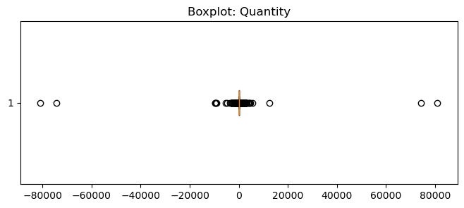

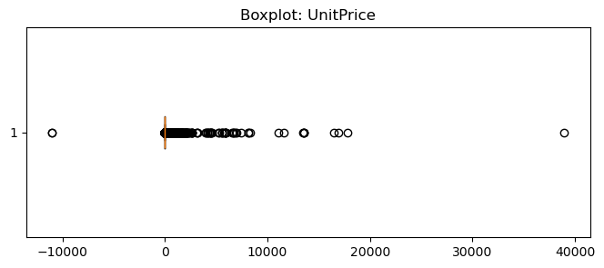

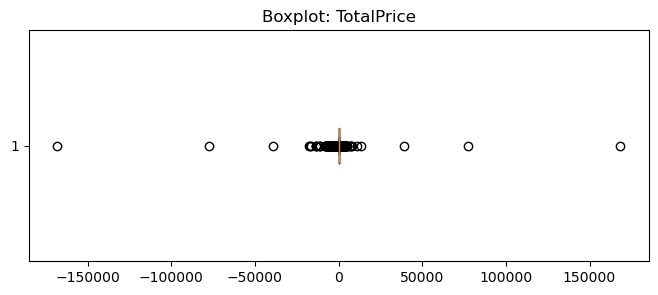

```python
# Biểu đồ hộp
for col in ["Quantity","UnitPrice","TotalPrice"]:
    plt.figure(figsize=(8,3))
    plt.boxplot(df[col].dropna(), vert=False)
    plt.title(f"Boxplot: {col}")
    plt.show()
```

### 7. Phân tích khách hàng (RFM Analysis)

Dựa trên mô hình **RFM (Recency - Frequency - Monetary)**:

```python
# Requires InvoiceDate, CustomerID, TotalPrice
snapshot_date = df["InvoiceDate"].max() + pd.Timedelta(days=1)
rfm = df[~df["IsReturn"]].groupby("CustomerID").agg({
    "InvoiceDate": lambda x: (snapshot_date - x.max()).days,
    "InvoiceNo": "nunique",
    "TotalPrice": "sum"
}).rename(columns={"InvoiceDate":"Recency","InvoiceNo":"Frequency","TotalPrice":"Monetary"}).reset_index()
display(rfm.sort_values("Monetary", ascending=False).head(10))
```

|  | CustomerID | Recency | Frequency | Monetary |
| --- | --- | --- | --- | --- |
| 1690 | 14646.0 | 2 | 74 | 280206.02 |
| 4202 | 18102.0 | 1 | 60 | 259657.30 |
| 3729 | 17450.0 | 8 | 46 | 194550.79 |
| 3009 | 16446.0 | 1 | 2 | 168472.50 |
| 1880 | 14911.0 | 1 | 201 | 143825.06 |
| 55 | 12415.0 | 24 | 21 | 124914.53 |
| 1334 | 14156.0 | 10 | 55 | 117379.63 |
| 3772 | 17511.0 | 3 | 31 | 91062.38 |
| 2703 | 16029.0 | 39 | 63 | 81024.84 |
| 0 | 12346.0 | 326 | 1 | 77183.60 |

```python
# Lưu file đã được làm sạch và các thông tin quan trọng
df.to_csv("online_retail_cleaned.csv", index=False)           # cleaned full dataset
monthly.to_csv("monthly_revenue.csv", index=False)
top_products_rev.to_csv("top_products_revenue.csv", index=False)
print("Saved: online_retail_cleaned.csv, monthly_revenue.csv, top_products_revenue.csv")
df.shape
```

```
Saved: online_retail_cleaned.csv, monthly_revenue.csv, top_products_revenue.csv
```

```
(541909, 11)
```

### 8. Kết luận chính từ EDA

- Dữ liệu cần được **làm sạch kỹ** (lọc giá trị âm, loại bỏ đơn trả hàng khi cần).
- Doanh thu tập trung vào **ít sản phẩm và ít khách hàng lớn**.
- **Mùa vụ và thời điểm** có ảnh hưởng mạnh đến doanh số.
- Có cơ hội khai thác thêm **phân tích hành vi khách hàng (Customer Segmentation)** để nâng cao hiệu quả marketing.

### 9. Đề xuất hướng phân tích tiếp theo

- Dự đoán doanh thu tháng kế tiếp (Time Series Forecasting).
- Phân nhóm khách hàng bằng K-Means dựa trên RFM.
- Phân tích giỏ hàng (Market Basket Analysis) để tìm mối quan hệ giữa các sản phẩm.